# Caracterização do desenvolvimento de bibliotecas multiplataforma

Daniel Moreira, Rodrigo Rocha

August 31, 2017

# Questões de pesquisa

- **QP1** - Como é a distribuição das tarefas de manutenção entre o código independente e específico de plataforma?

**QP1.1** Qual plataforma é modificada com mais frequência?

- **QP2** A equipe de desenvolvimento de bibliotecas multiplataforma é formada majoritariamente por desenvolvedores generalistas ou especialistas em plataformas?

**QP2.1** A equipe de desenvolvimento de bibliotecas multiplataforma tende a tornar-se mais generalista ou especialista ao longo do tempo?

**QP2.2** Dos desenvolvedores generalistas, eles tendem a trabalhar com mais plataformas ao longo do tempo?

- **QP3** - Os desenvolvedores de bibliotecas multiplataforma são majoritariamente especialistas em plataformas de um determinado tipo de dispositivo ou trabalham com plataformas de mais de um tipo de dispositivo?

**QP3.1** Os desenvolvedores de bibliotecas multiplataforma tendem a especializar-se em dispositivos desktop ou mobile ao longo do tempo?

- **QP4** - Existem relações entre os conjuntos de plataformas que os desenvolvedores dão suporte?

**QP4.1** Com quantas plataformas cada desenvolvedor trabalha?

**QP4.2** Dos desenvolvedores que trabalham com uma plataforma, como é a distribuição de plataformas?

**QP4.3** Dos desenvolvedores que trabalham com mais de uma plataforma, qual a porcentagem de desenvolvedores que trabalham com o código independente e outras plataformas?

- **QP5** - Existem relações entre os conjuntos de plataformas modificadas em um commit?

**QP5.1** Quantas plataformas são modificadas em conjunto em um commit?

**QP5.2** Dos commits que modificaram uma plataforma, como é a distribuição de plataformas?

**QP5.3** Dos commits que modificaram mais de uma plataforma, qual a porcentagem de commits que modificaram o código independente junto com o código específico de alguma plataforma?

# Resultados - Análise quantitativa

### Allegro

#### QP1 - Como é a distribuição de tarefas de manutenção entre o código independente e específico de plataforma?

##### Especifico -> Soma da quantidade de vezes que o código específico de cada plataforma é modificado.

##### Independente -> Quantidade de vezes que o codigo independente é modificado sozinho

##### especifico -> Quantidade de vezes que o codigo especifico de uma ou mais plataformas é modificado

##### ambos -> Quantidade de vezes que o codigo especifico e independente de uma ou mais plataformas sao modificados em conjunto

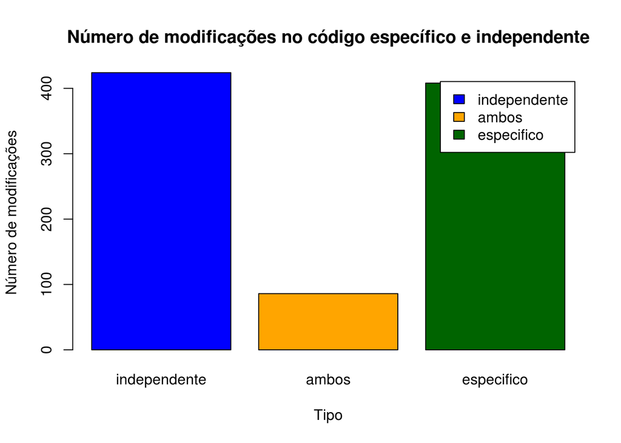

##### QP1.1 Qual plataforma é modificada com mais frequência?.

##### Contamos a quantidade de vezes que o código específico de cada plataforma é modificado.

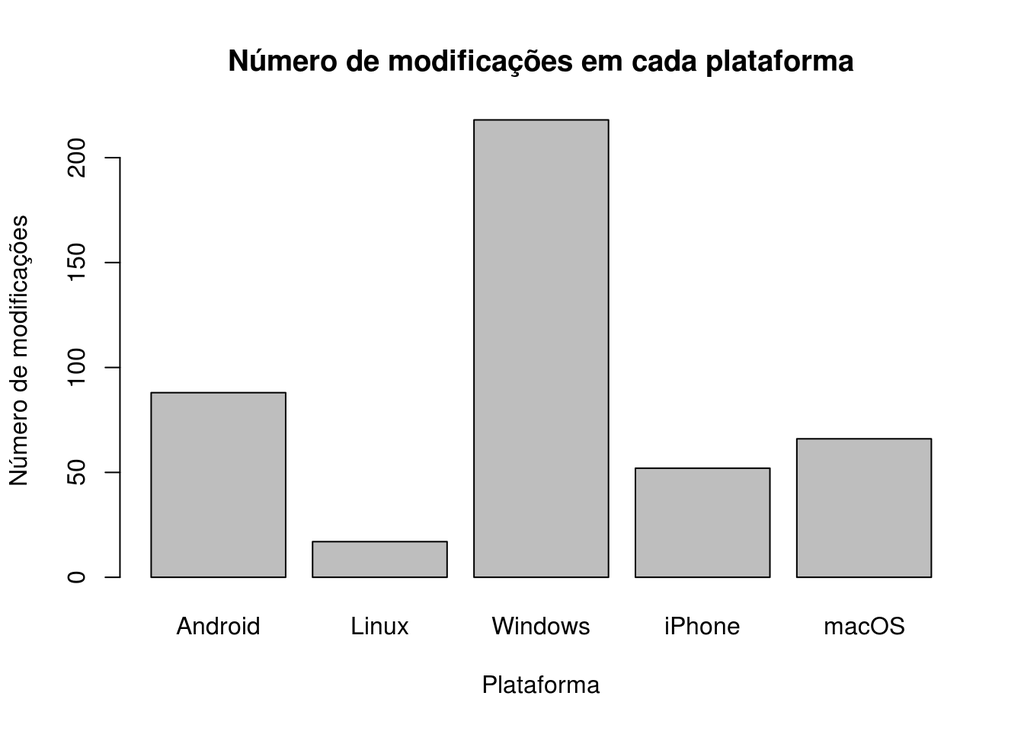

#### QP2 - A equipe de desenvolvimento de bibliotecas multiplataforma é formada majoritariamente por desenvolvedores generalistas ou especialistas em plataformas?

##### esp -> desenvolvedores que trabalham apenas com uma plataforma.

##### gen -> desenvolvedores que trabalham com mais de uma plataforma.

##### NA -> desenvolvedores que tranbalham apenas com o código independente.

| tipo | n | porc_dev |
| --- | --- | --- |
| esp | 7 | 31.8 |
| gen | 11 | 50.0 |
| NA | 4 | 18.2 |

##### QP2.1 - A equipe de desenvolvimento de bibliotecas multiplataforma tende a tornar-se mais generalista ou especialita em plataformas ao lonto do tempo?

#### QP3 - Os desenvolvedores de bibliotecas multiplataforma são especialistas em plataformas de um determinado tipo de dispositivo ou trabalham com plataformas de mais de um tipo de dispositivo?

##### None -> desenvolvedores que tranbalham apenas com o código independente.

##### Desktop -> desenvolvedores que tranbalham apenas com o código plataformas de dispositivos desktop

##### Mobile -> desenvolvedores que tranbalham apenas com o código plataformas de dispositivos mobile

##### Both -> desenvolvedores que tranbalham com o código plataformas de dispositivos mobile e desktop

| dispositivo | n_todos | porc_todos |
| --- | --- | --- |
| None | 4 | 18.181818 |
| Desktop | 5 | 22.727273 |
| Mobile | 2 | 9.090909 |
| Both | 11 | 50.000000 |

##### QP3.1 - A equipe de desenvolvimento de bibliotecas multiplataforma tende a tornar-se mais generalista ou especialita em dipositivos ao lonto do tempo?

#### QP4 - Existem relações entre os conjuntos de plataformas que os desenvolvedores suportam?

|  | lhs |  | rhs | support | confidence | lift | count |
| --- | --- | --- | --- | --- | --- | --- | --- |
| [1] | {win} | => | {independente} | 0.4545455 | 0.9090909 | 1.250000 | 10 |
| 2 | {android} | => | {independente} | 0.4090909 | 0.8181818 | 1.125000 | 9 |
| 3 | {win,macosx} | => | {independente} | 0.3636364 | 1.0000000 | 1.375000 | 8 |
| 4 | {macosx,independente} | => | {win} | 0.3636364 | 0.8888889 | 1.777778 | 8 |
| 5 | {win,independente} | => | {macosx} | 0.3636364 | 0.8000000 | 1.466667 | 8 |
| [6] | {android,win} | => | {independente} | 0.3636364 | 1.0000000 | 1.375000 | 8 |
| [7] | {android,independente} | => | {win} | 0.3636364 | 0.8888889 | 1.777778 | 8 |
| [8] | {win,independente} | => | {android} | 0.3636364 | 0.8000000 | 1.600000 | 8 |
| [9] | {iphone} | => | {win} | 0.3181818 | 1.0000000 | 2.000000 | 7 |
| [10] | {iphone} | => | {independente} | 0.3181818 | 1.0000000 | 1.375000 | 7 |

###### Afinidade (desenvolvedor)

|  | android | linux | win | iphone | macosx | independente |
| --- | --- | --- | --- | --- | --- | --- |
| android | 0.0000000 | 0.5454545 | 0.5714286 | 0.3846154 | 0.4375000 | 0.5000000 |
| linux | 0.5454545 | 0.0000000 | 0.4166667 | 0.4444444 | 0.2857143 | 0.2941176 |
| win | 0.5714286 | 0.4166667 | 0.0000000 | 0.6363636 | 0.5333333 | 0.5882353 |
| iphone | 0.3846154 | 0.4444444 | 0.6363636 | 0.0000000 | 0.4615385 | 0.4375000 |
| macosx | 0.4375000 | 0.2857143 | 0.5333333 | 0.4615385 | 0.0000000 | 0.4736842 |
| independente | 0.5000000 | 0.2941176 | 0.5882353 | 0.4375000 | 0.4736842 | 0.0000000 |

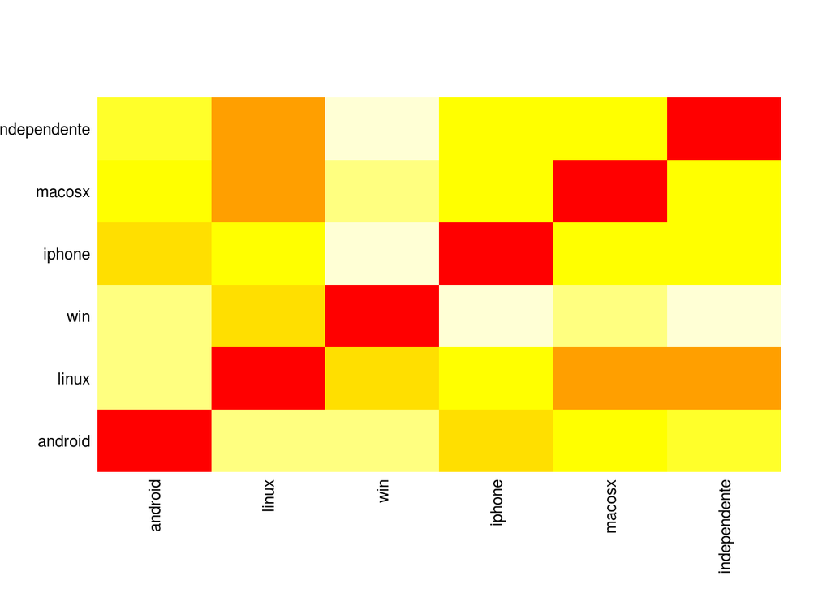

###### Crosstable entre as plataformas (count) (desenvolvedor)

|  | independente | macosx | android | win | iphone | linux |
| --- | --- | --- | --- | --- | --- | --- |
| independente | 16 | 9 | 9 | 10 | 7 | 5 |
| macosx | 9 | 12 | 7 | 8 | 6 | 4 |
| android | 9 | 7 | 11 | 8 | 5 | 6 |
| win | 10 | 8 | 8 | 11 | 7 | 5 |
| iphone | 7 | 6 | 5 | 7 | 7 | 4 |
| linux | 5 | 4 | 6 | 5 | 4 | 6 |

###### Crosstable entre as plataformas (support) (desenvolvedor)

|  | independente | macosx | android | win | iphone | linux |
| --- | --- | --- | --- | --- | --- | --- |
| independente | 0.7272727 | 0.4090909 | 0.4090909 | 0.4545455 | 0.3181818 | 0.2272727 |
| macosx | 0.4090909 | 0.5454545 | 0.3181818 | 0.3636364 | 0.2727273 | 0.1818182 |
| android | 0.4090909 | 0.3181818 | 0.5000000 | 0.3636364 | 0.2272727 | 0.2727273 |
| win | 0.4545455 | 0.3636364 | 0.3636364 | 0.5000000 | 0.3181818 | 0.2272727 |
| iphone | 0.3181818 | 0.2727273 | 0.2272727 | 0.3181818 | 0.3181818 | 0.1818182 |
| linux | 0.2272727 | 0.1818182 | 0.2727273 | 0.2272727 | 0.1818182 | 0.2727273 |

##### QP4.1 - Qual a quantidade de plataformas que os desenvolvedores dão suporte?

##### Consideramos as plataformas Windows, Linux, macOS, iPhone e Android nesta contagem.

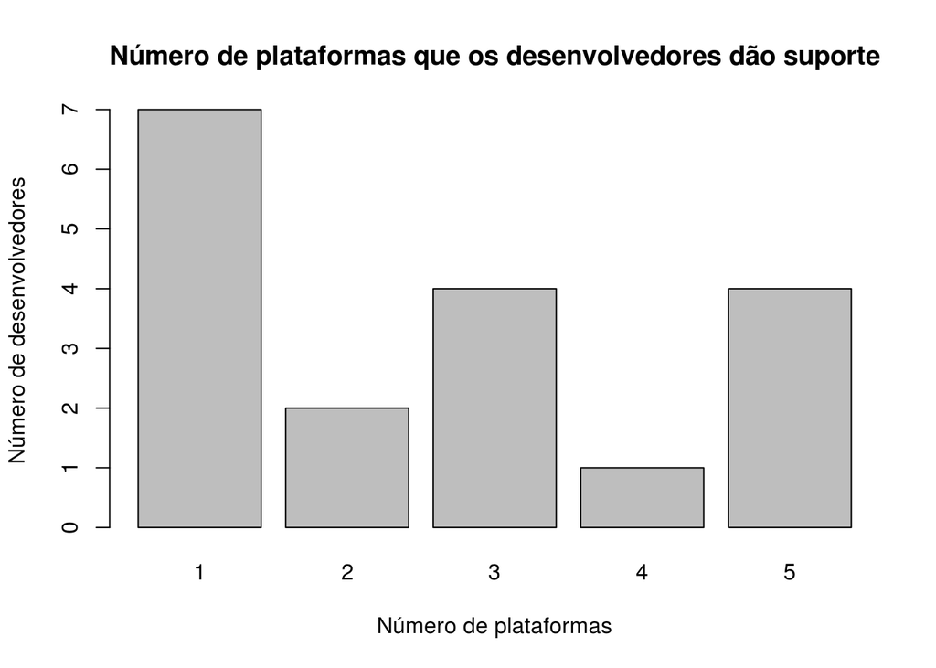

##### QP4.2 - Dos desenvolvedores que trabalham com uma plataforma, como é a distribuição das plataformas?

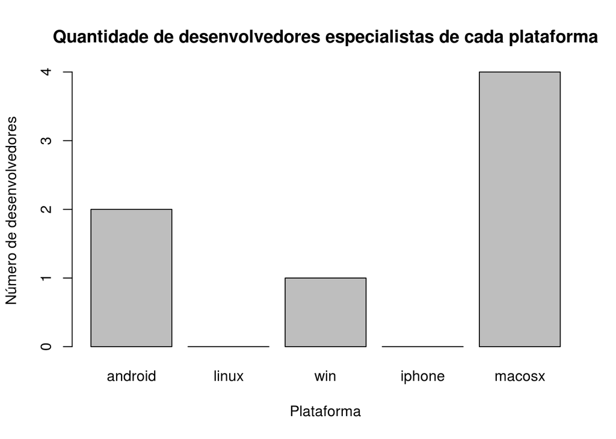

##### QP4.3 - Dos desenvolvedores generalistas, qual a quantidade de plataformas que eles dão suporte?

| n_platform | n_dev_gen | porc_gen |
| --- | --- | --- |
| 2 | 2 | 18.2 |
| 3 | 4 | 36.4 |
| 4 | 1 | 9.1 |
| 5 | 4 | 36.4 |

#### QP5 - Existem relações entre os conjuntos de plataformas modificadas em um commit?

###### Consideramos nesta analise as plataformas suportadas pela biblioteca e o código independente é interpretado como uma plataforma.

|  | lhs |  | rhs | support | confidence | lift | count |
| --- | --- | --- | --- | --- | --- | --- | --- |
| [1] | {Windows,iPhone} | => | {Independente} | 0.0108173 | 1.0 | 1.637795 | 9 |
| 2 | {Windows,macOS} | => | {Independente} | 0.0108173 | 1.0 | 1.637795 | 9 |
| 3 | {Android,Windows} | => | {Independente} | 0.0084135 | 1.0 | 1.637795 | 7 |
| 4 | {Linux,Windows} | => | {Independente} | 0.0060096 | 1.0 | 1.637795 | 5 |
| 5 | {iPhone,macOS} | => | {Windows} | 0.0048077 | 1.0 | 3.816514 | 4 |
| [6] | {iPhone,macOS} | => | {Independente} | 0.0048077 | 1.0 | 1.637795 | 4 |
| [7] | {Android,iPhone} | => | {Windows} | 0.0048077 | 0.8 | 3.053211 | 4 |
| [8] | {Android,iPhone} | => | {Independente} | 0.0048077 | 0.8 | 1.310236 | 4 |
| [9] | {Windows,iPhone,macOS} | => | {Independente} | 0.0048077 | 1.0 | 1.637795 | 4 |
| [10] | {iPhone,macOS,Independente} | => | {Windows} | 0.0048077 | 1.0 | 3.816514 | 4 |

###### Afinidade (commit)

|  | Android | Linux | Windows | iPhone | macOS | Independente |
| --- | --- | --- | --- | --- | --- | --- |
| Android | 0.0000000 | 0.0194175 | 0.0234114 | 0.0370370 | 0.0198675 | 0.0365217 |
| Linux | 0.0194175 | 0.0000000 | 0.0217391 | 0.0147059 | 0.0000000 | 0.0174419 |
| Windows | 0.0234114 | 0.0217391 | 0.0000000 | 0.0344828 | 0.0327273 | 0.0884558 |
| iPhone | 0.0370370 | 0.0147059 | 0.0344828 | 0.0000000 | 0.0350877 | 0.0256410 |
| macOS | 0.0198675 | 0.0000000 | 0.0327273 | 0.0350877 | 0.0000000 | 0.0213523 |
| Independente | 0.0365217 | 0.0174419 | 0.0884558 | 0.0256410 | 0.0213523 | 0.0000000 |

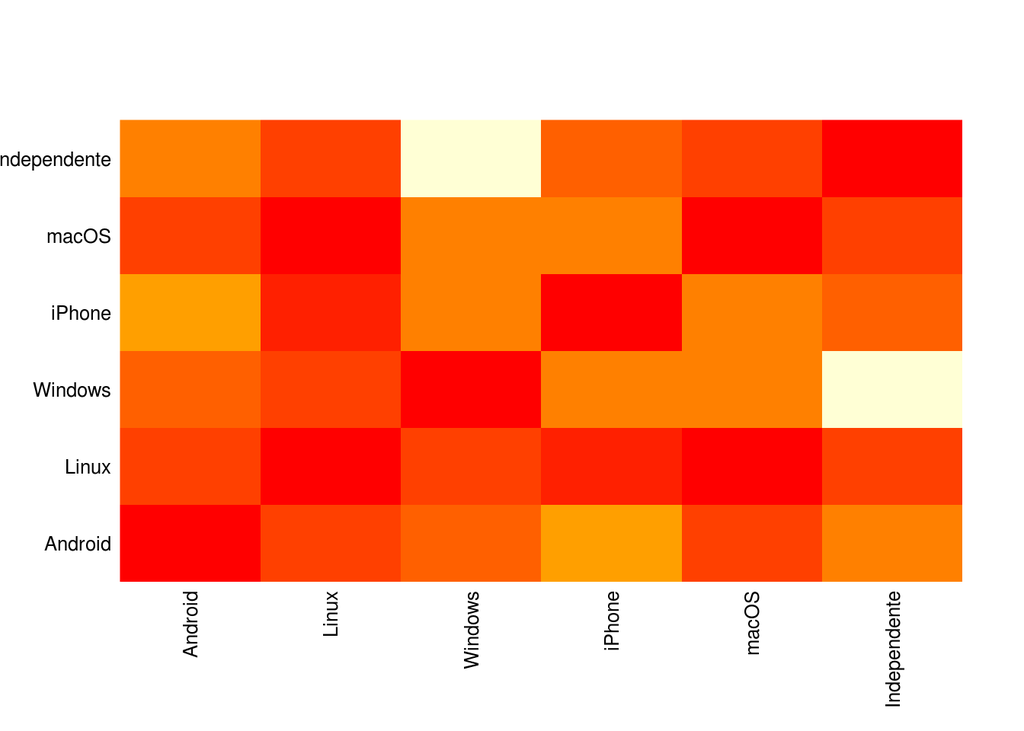

###### Crosstable entre as plataformas (count) (commit)

|  | Independente | Windows | Android | macOS | iPhone | Linux |
| --- | --- | --- | --- | --- | --- | --- |
| Independente | 508 | 59 | 21 | 12 | 14 | 9 |
| Windows | 59 | 218 | 7 | 9 | 9 | 5 |
| Android | 21 | 7 | 88 | 3 | 5 | 2 |
| macOS | 12 | 9 | 3 | 66 | 4 | 0 |
| iPhone | 14 | 9 | 5 | 4 | 52 | 1 |
| Linux | 9 | 5 | 2 | 0 | 1 | 17 |

###### Crosstable entre as plataformas (support) (commit)

|  | Independente | Windows | Android | macOS | iPhone | Linux |
| --- | --- | --- | --- | --- | --- | --- |
| Independente | 0.6105769 | 0.0709135 | 0.0252404 | 0.0144231 | 0.0168269 | 0.0108173 |
| Windows | 0.0709135 | 0.2620192 | 0.0084135 | 0.0108173 | 0.0108173 | 0.0060096 |
| Android | 0.0252404 | 0.0084135 | 0.1057692 | 0.0036058 | 0.0060096 | 0.0024038 |
| macOS | 0.0144231 | 0.0108173 | 0.0036058 | 0.0793269 | 0.0048077 | 0.0000000 |
| iPhone | 0.0168269 | 0.0108173 | 0.0060096 | 0.0048077 | 0.0625000 | 0.0012019 |
| Linux | 0.0108173 | 0.0060096 | 0.0024038 | 0.0000000 | 0.0012019 | 0.0204327 |

#### QP5.1 - Quantas plataformas são modificadas em conjunto em uma tarefa de manutenção?

| Platform | Commit | % |
| --- | --- | --- |
| 0 | 424 | 51.0 |
| 1 | 384 | 46.2 |
| 2 | 18 | 2.2 |
| 3 | 3 | 0.4 |
| 4 | 3 | 0.4 |

##### QP5.2 - Dos commits que modificaram uma plataforma, como é a distribuição de plataformas?

##### Distribuição de plataformas dos commits que modificaram apenas o código especifico de uma plataforma

| Platform | Mod. Total | Mod. uma | % moduma_modtotal | modtotal_summodtotal |
| --- | --- | --- | --- | --- |
| Android | 88 | 65 | 73.86364 | 19.954649 |
| iPhone | 52 | 37 | 71.15385 | 11.791383 |
| Linux | 17 | 7 | 41.17647 | 3.854875 |
| macOS | 66 | 54 | 81.81818 | 14.965986 |
| Windows | 218 | 159 | 72.93578 | 49.433107 |

##### QP5.3 - Qual a porcentagem de commits que modificaram o código independente junto com algum código específico de plataforma?

##### Neste calculo de porcentagem consideramos como denominador o número total de commits que modificaram o código específico de alguma

Total de commits: [1] 832

Total de commits que modificaram o código específico de pelo menos uma plataforma (Denominador): [1] 408

Porcentagem: [1] 20.58824

#### QP2.1 - A equipe de desenvolvimento de bibliotecas multiplataforma tende a tornar-se mais generalista ou especialista ao longo do tempo?

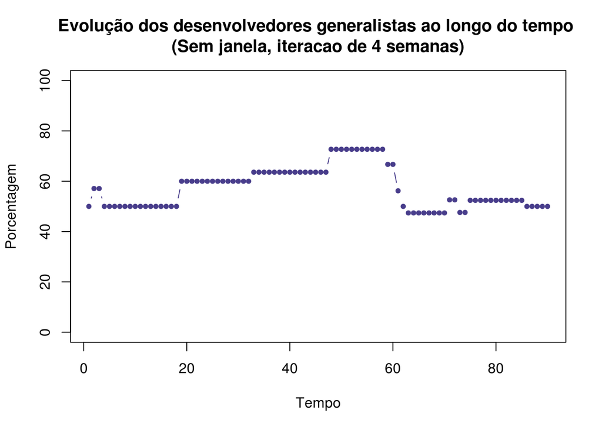

```
KPSS Test for Level Stationarity
```

data: dev_all_time2$porcentage KPSS Level = 0.54673, Truncation lag parameter = 2, p-value = 0.03114

```
KPSS Test for Trend Stationarity
```

data: dev_all_time2$porcentage KPSS Trend = 0.52377, Truncation lag parameter = 2, p-value = 0.01

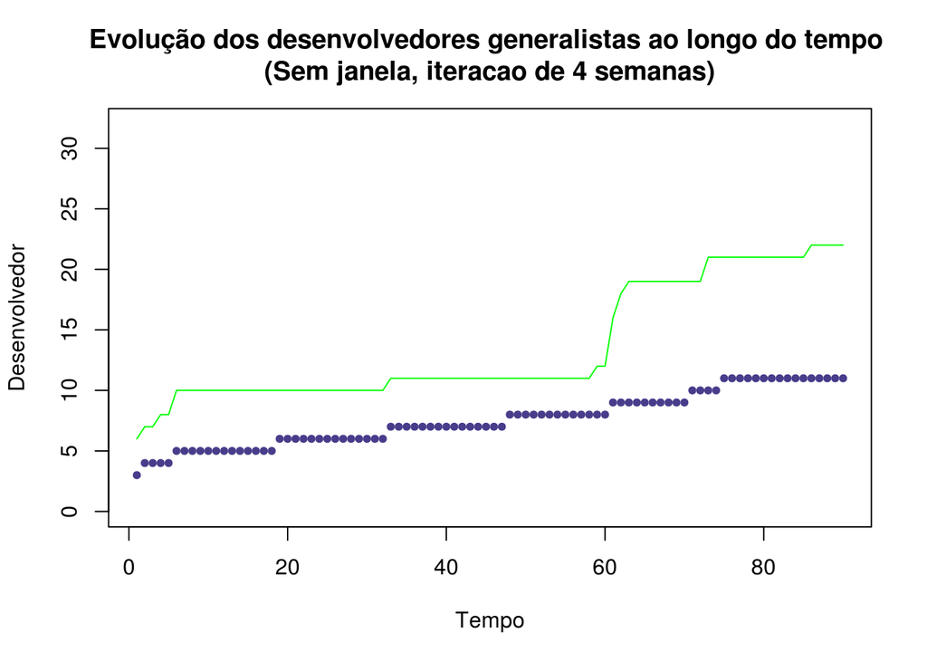

```
KPSS Test for Level Stationarity
```

data: dev_all_time2$n KPSS Level = 3.0066, Truncation lag parameter = 2, p-value = 0.01

```
KPSS Test for Trend Stationarity
```

data: dev_all_time2$n KPSS Trend = 0.2305, Truncation lag parameter = 2, p-value = 0.01

#### QP2.2 - Dos desenvolvedores generalistas, eles tendem a trabalhar com mais plataformas ao longo do tempo?

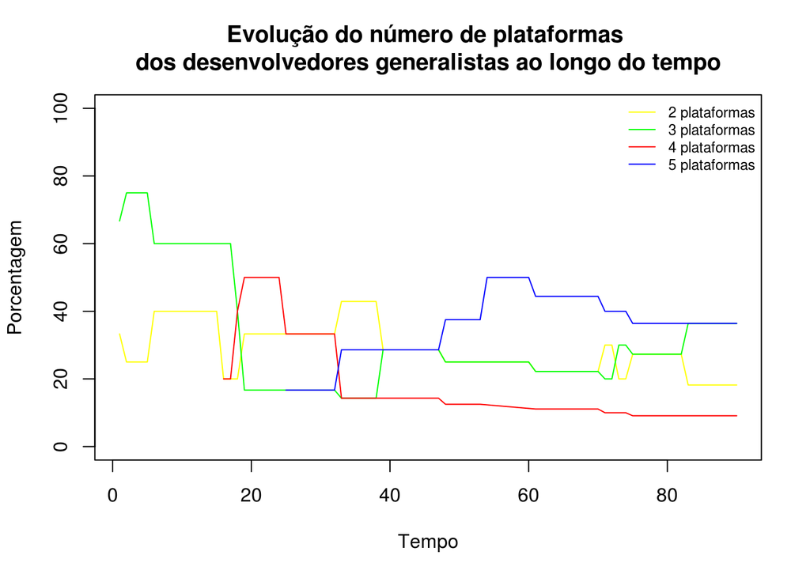

#### 2

```
KPSS Test for Level Stationarity
```

data: dev_gen_time2$porcentage KPSS Level = 1.605, Truncation lag parameter = 2, p-value = 0.01

```
KPSS Test for Trend Stationarity
```

data: dev_gen_time2$porcentage KPSS Trend = 0.11711, Truncation lag parameter = 2, p-value = 0.1

#### 3

```
KPSS Test for Level Stationarity
```

data: dev_gen_time3$porcentage KPSS Level = 0.99555, Truncation lag parameter = 2, p-value = 0.01

```
KPSS Test for Trend Stationarity
```

data: dev_gen_time3$porcentage KPSS Trend = 0.51254, Truncation lag parameter = 2, p-value = 0.01

#### 4

```
KPSS Test for Level Stationarity
```

data: dev_gen_time4$porcentage KPSS Level = 2.267, Truncation lag parameter = 1, p-value = 0.01

```
KPSS Test for Trend Stationarity
```

data: dev_gen_time4$porcentage KPSS Trend = 0.43433, Truncation lag parameter = 1, p-value = 0.01

#### 5

```
KPSS Test for Level Stationarity
```

data: dev_gen_time5$porcentage KPSS Level = 1.755, Truncation lag parameter = 1, p-value = 0.01

```
KPSS Test for Trend Stationarity
```

data: dev_gen_time5$porcentage KPSS Trend = 0.71193, Truncation lag parameter = 1, p-value = 0.01

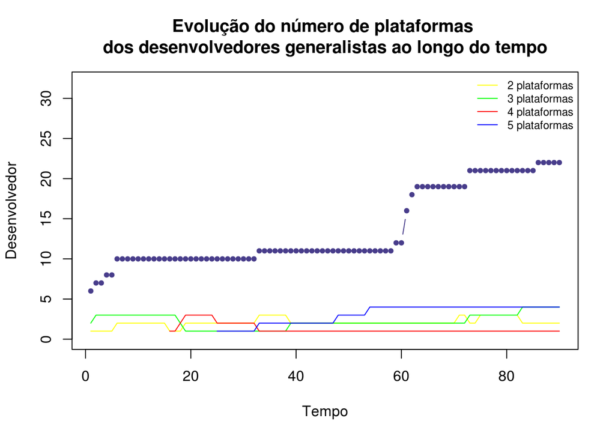

#### 2

```
KPSS Test for Level Stationarity
```

data: dev_gen_time2$n KPSS Level = 0.84244, Truncation lag parameter = 2, p-value = 0.01

```
KPSS Test for Trend Stationarity
```

data: dev_gen_time2$n KPSS Trend = 0.12871, Truncation lag parameter = 2, p-value = 0.08201

#### 3

```
KPSS Test for Level Stationarity
```

data: dev_gen_time3$n KPSS Level = 0.87846, Truncation lag parameter = 2, p-value = 0.01

```
KPSS Test for Trend Stationarity
```

data: dev_gen_time3$n KPSS Trend = 0.52534, Truncation lag parameter = 2, p-value = 0.01

#### 4

```
KPSS Test for Level Stationarity
```

data: dev_gen_time4$n KPSS Level = 1.6751, Truncation lag parameter = 1, p-value = 0.01

```
KPSS Test for Trend Stationarity
```

data: dev_gen_time4$n KPSS Trend = 0.39145, Truncation lag parameter = 1, p-value = 0.01

#### 5

```
KPSS Test for Level Stationarity
```

data: dev_gen_time5$n KPSS Level = 2.8882, Truncation lag parameter = 1, p-value = 0.01

```
KPSS Test for Trend Stationarity
```

data: dev_gen_time5$n KPSS Trend = 0.65918, Truncation lag parameter = 1, p-value = 0.01

#### QP3.1 - Os desenvolvedores de bibliotecas multiplataforma tendem a especializar-se em dispositivos desktop ou mobile ao longo do tempo?

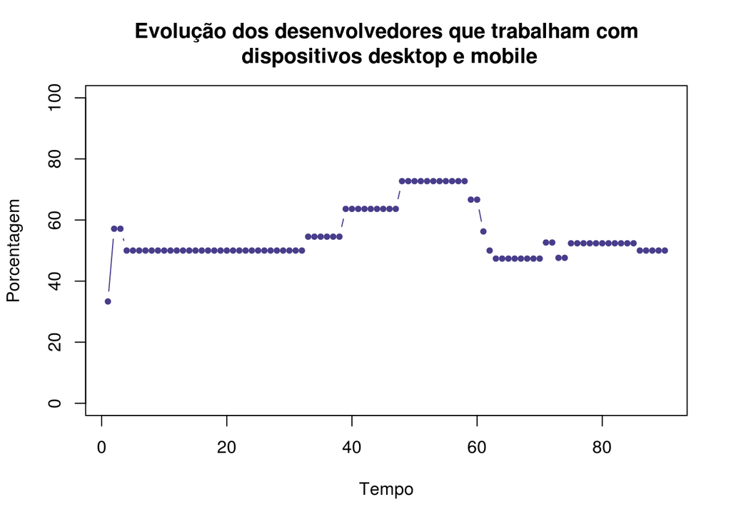

```
KPSS Test for Level Stationarity
```

data: devicetype_time2$porcentage KPSS Level = 0.50908, Truncation lag parameter = 2, p-value = 0.03962

```
KPSS Test for Trend Stationarity
```

data: devicetype_time2$porcentage KPSS Trend = 0.4516, Truncation lag parameter = 2, p-value = 0.01

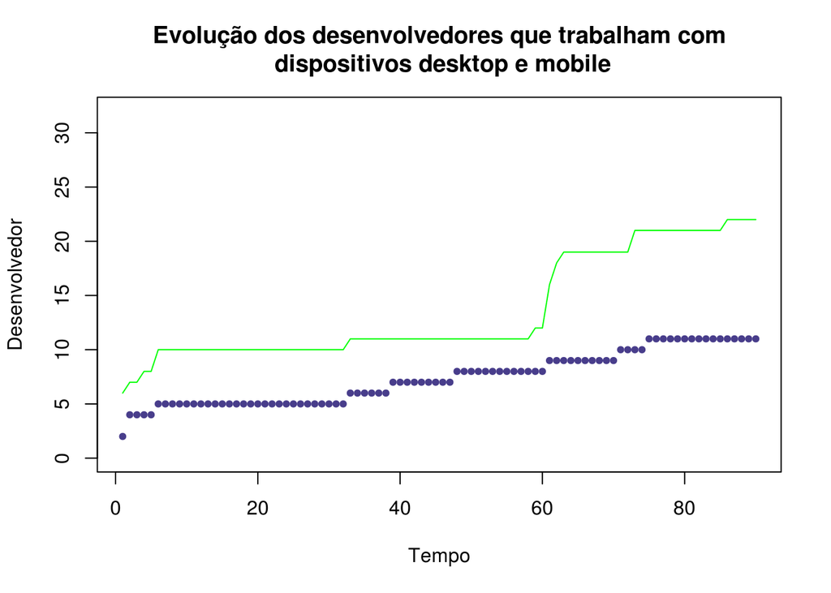

```
KPSS Test for Level Stationarity
```

data: devicetype_time2$developer KPSS Level = 3.0273, Truncation lag parameter = 2, p-value = 0.01

```
KPSS Test for Trend Stationarity
```

data: devicetype_time2$developer KPSS Trend = 0.30648, Truncation lag parameter = 2, p-value = 0.01

#### Análise temporal com janela deslizante

#### Janela de 24 semanas

#### QP2.1 - A equipe de desenvolvimento de bibliotecas multiplataforma tende a tornar-se mais generalista ou especialista ao longo do tempo?

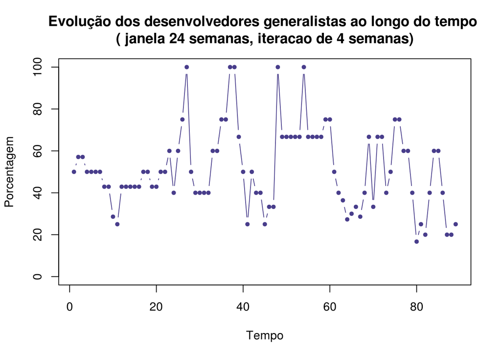

```
KPSS Test for Level Stationarity
```

data: dev_all_time24_2$porcentage KPSS Level = 0.19834, Truncation lag parameter = 2, p-value = 0.1

```
KPSS Test for Trend Stationarity
```

data: dev_all_time24_2$porcentage KPSS Trend = 0.18002, Truncation lag parameter = 2, p-value = 0.02349

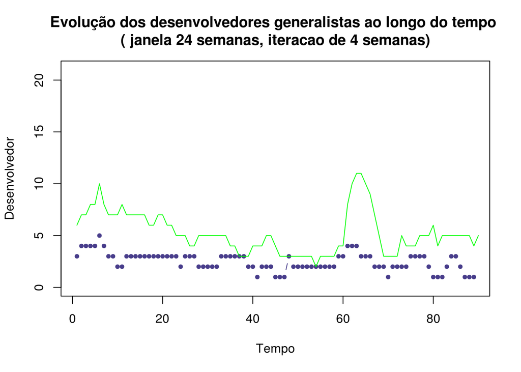

```
KPSS Test for Level Stationarity
```

data: dev_all_time24_2$n KPSS Level = 0.87471, Truncation lag parameter = 2, p-value = 0.01

```
KPSS Test for Trend Stationarity
```

data: dev_all_time24_2$n KPSS Trend = 0.14319, Truncation lag parameter = 2, p-value = 0.05521

#### QP2.2 - Dos desenvolvedores generalistas, eles tendem a trabalhar com mais plataformas ao longo do tempo?

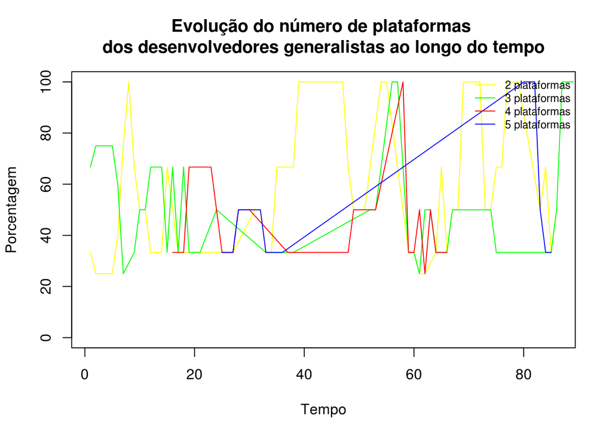

#### 2

```
KPSS Test for Level Stationarity
```

data: dev_gen_time24_2$porcentage KPSS Level = 0.59267, Truncation lag parameter = 1, p-value = 0.0233

```
KPSS Test for Trend Stationarity
```

data: dev_gen_time24_2$porcentage KPSS Trend = 0.15491, Truncation lag parameter = 1, p-value = 0.04257

#### 3

```
KPSS Test for Level Stationarity
```

data: dev_gen_time24_3$porcentage KPSS Level = 0.14015, Truncation lag parameter = 1, p-value = 0.1

```
KPSS Test for Trend Stationarity
```

data: dev_gen_time24_3$porcentage KPSS Trend = 0.13833, Truncation lag parameter = 1, p-value = 0.06421

#### 4

```
KPSS Test for Level Stationarity
```

data: dev_gen_time24_4$porcentage KPSS Level = 0.14803, Truncation lag parameter = 1, p-value = 0.1

```
KPSS Test for Trend Stationarity
```

data: dev_gen_time24_4$porcentage KPSS Trend = 0.068223, Truncation lag parameter = 1, p-value = 0.1

#### 5

```
KPSS Test for Level Stationarity
```

data: dev_gen_time24_5$porcentage KPSS Level = 0.32542, Truncation lag parameter = 0, p-value = 0.1

```
KPSS Test for Trend Stationarity
```

data: dev_gen_time24_5$porcentage KPSS Trend = 0.10324, Truncation lag parameter = 0, p-value = 0.1

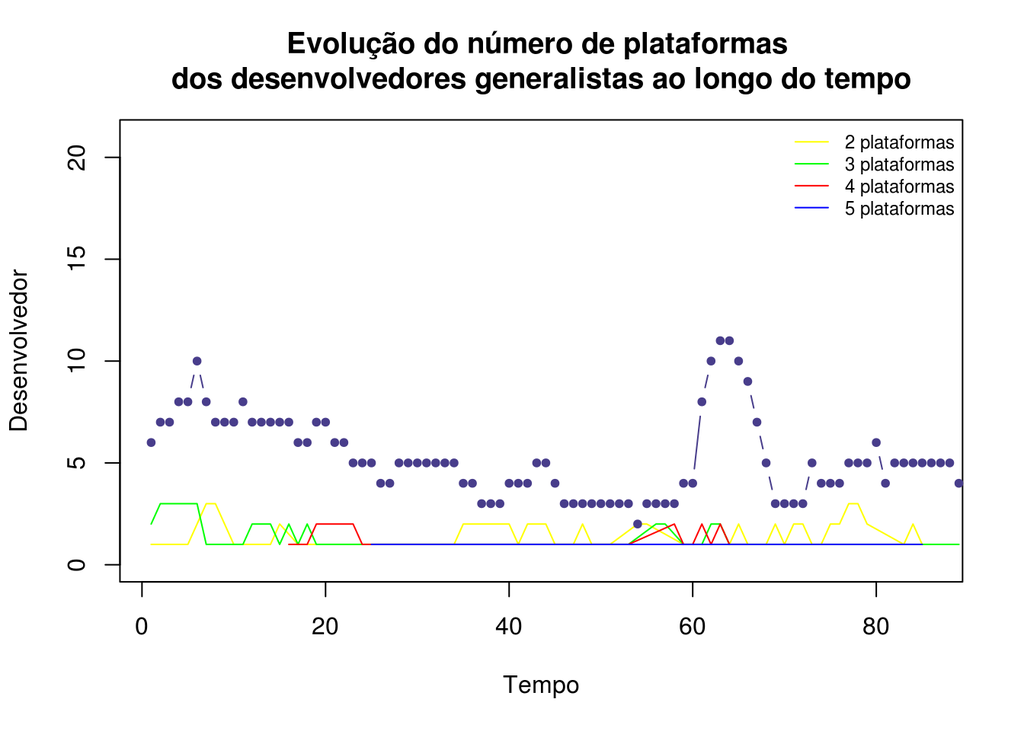

#### 2

```
KPSS Test for Level Stationarity
```

data: dev_gen_time24_2$n KPSS Level = 0.1367, Truncation lag parameter = 1, p-value = 0.1

```
KPSS Test for Trend Stationarity
```

data: dev_gen_time24_2$n KPSS Trend = 0.062689, Truncation lag parameter = 1, p-value = 0.1

#### 3

```
KPSS Test for Level Stationarity
```

data: dev_gen_time24_3$n KPSS Level = 0.95653, Truncation lag parameter = 1, p-value = 0.01

```
KPSS Test for Trend Stationarity
```

data: dev_gen_time24_3$n KPSS Trend = 0.16533, Truncation lag parameter = 1, p-value = 0.03389

#### 4

```
KPSS Test for Level Stationarity
```

data: dev_gen_time24_4$n KPSS Level = 0.19587, Truncation lag parameter = 1, p-value = 0.1

```
KPSS Test for Trend Stationarity
```

data: dev_gen_time24_4$n KPSS Trend = 0.12175, Truncation lag parameter = 1, p-value = 0.09491

#### 5

```
KPSS Test for Level Stationarity
```

data: dev_gen_time24_5$n KPSS Level = 0.32407, Truncation lag parameter = 0, p-value = 0.1

```
KPSS Test for Trend Stationarity
```

data: dev_gen_time24_5$n KPSS Trend = 0.12963, Truncation lag parameter = 0, p-value = 0.08032

#### QP3.1 - Os desenvolvedores de bibliotecas multiplataforma tendem a especializar-se em dispositivos desktop ou mobile ao longo do tempo?

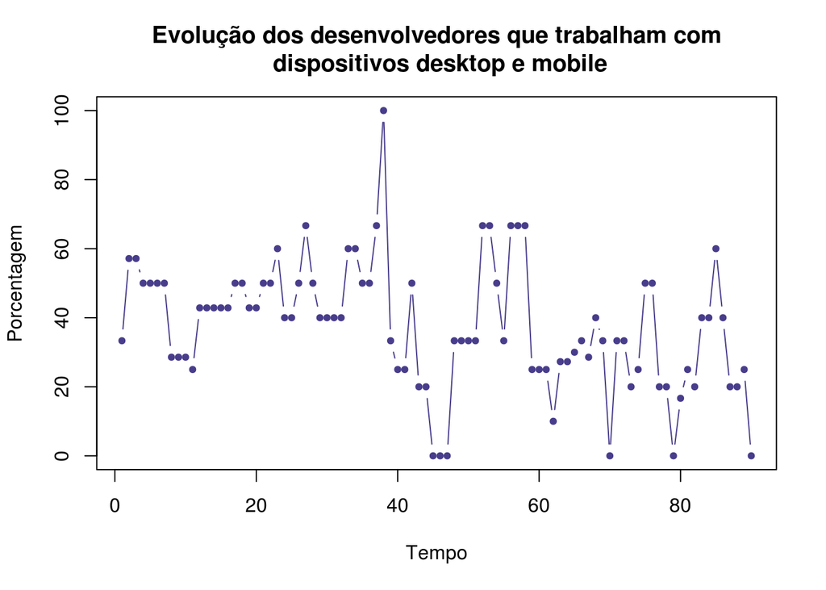

```
KPSS Test for Level Stationarity
```

data: devicetype_time24_2$porcentage KPSS Level = 0.72674, Truncation lag parameter = 2, p-value = 0.01111

```
KPSS Test for Trend Stationarity
```

data: devicetype_time24_2$porcentage KPSS Trend = 0.058864, Truncation lag parameter = 2, p-value = 0.1

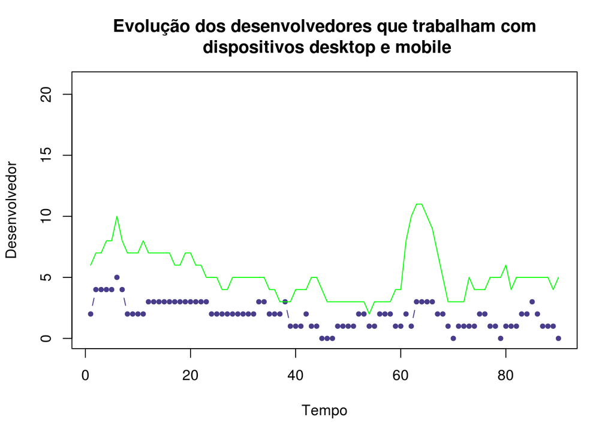

```
KPSS Test for Level Stationarity
```

data: devicetype_time24_2$developer KPSS Level = 1.4391, Truncation lag parameter = 2, p-value = 0.01

```
KPSS Test for Trend Stationarity
```

data: devicetype_time24_2$developer KPSS Trend = 0.20312, Truncation lag parameter = 2, p-value = 0.01483

#### Rastreamento dos desenvolvedores

Selecionamos os desenvolvedores que comitaram nas primeiras 24 semanas do periodo de análise e verificamos o numero de plataformas que eles fizeram trabalharam em cada janela de tempo

As plataformas consideradas foram: win, iphone, linux, macos, e android

Filtrei alguns desenvolvedores com poucos commits pq o plot.ts so aceita matriz de ate 10 colunas

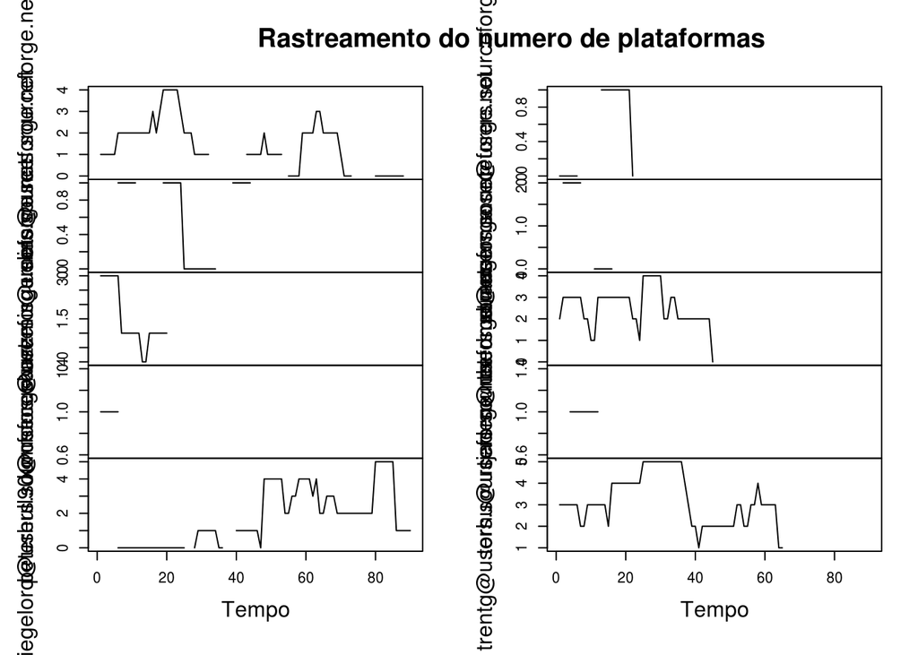

## ————————————————————————-

### SDL

#### QP1 - Como é a distribuição de tarefas de manutenção entre o código independente e específico de plataforma?

##### Especifico -> Soma da quantidade de vezes que o código específico de cada plataforma é modificado.

##### Independente -> Quantidade de vezes que o codigo independente é modificado sozinho

##### especifico -> Quantidade de vezes que o codigo especifico de uma ou mais plataformas é modificado

##### ambos -> Quantidade de vezes que o codigo especifico e independente de uma ou mais plataformas sao modificados em conjunto

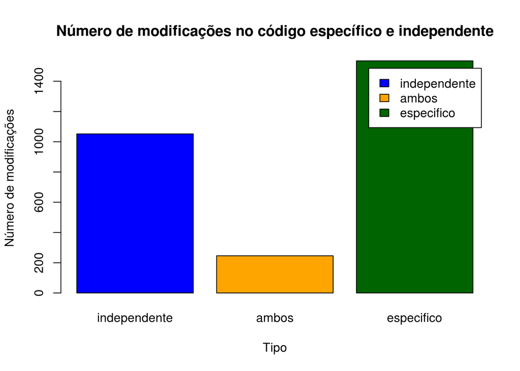

##### QP1.1 Qual plataforma é modificada com mais frequência?.

##### Contamos a quantidade de vezes que o código específico de cada plataforma é modificado.

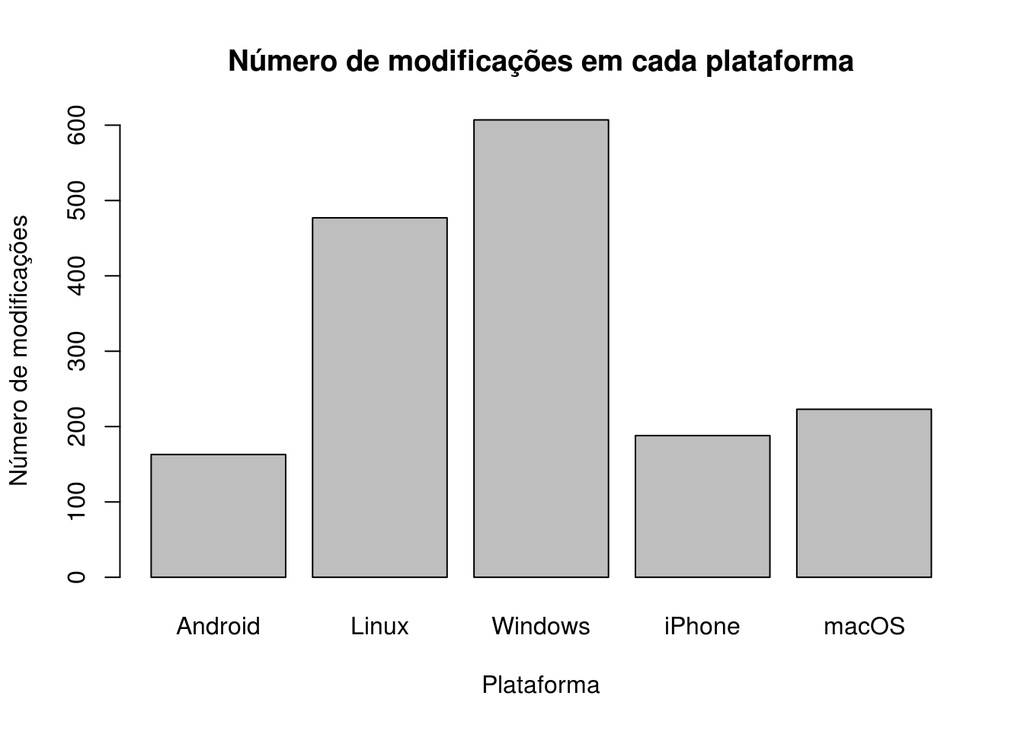

#### QP2 - A equipe de desenvolvimento de bibliotecas multiplataforma é formada majoritariamente por desenvolvedores generalistas ou especialistas em plataformas?

##### esp -> desenvolvedores que trabalham apenas com uma plataforma.

##### gen -> desenvolvedores que trabalham com mais de uma plataforma.

##### NA -> desenvolvedores que tranbalham apenas com o código independente.

| tipo | n | porc_dev |
| --- | --- | --- |
| esp | 35 | 49.3 |
| gen | 17 | 23.9 |
| NA | 19 | 26.8 |

##### QP2.1 - A equipe de desenvolvimento de bibliotecas multiplataforma tende a tornar-se mais generalista ou especialita em plataformas ao lonto do tempo?

#### QP3 - Os desenvolvedores de bibliotecas multiplataforma são especialistas em plataformas de um determinado tipo de dispositivo ou trabalham com plataformas de mais de um tipo de dispositivo?

##### None -> desenvolvedores que tranbalham apenas com o código independente.

##### Desktop -> desenvolvedores que tranbalham apenas com o código plataformas de dispositivos desktop

##### Mobile -> desenvolvedores que tranbalham apenas com o código plataformas de dispositivos mobile

##### Both -> desenvolvedores que tranbalham com o código plataformas de dispositivos mobile e desktop

| dispositivo | n_todos | porc_todos |
| --- | --- | --- |
| None | 19 | 26.76056 |
| Desktop | 36 | 50.70423 |
| Mobile | 8 | 11.26761 |
| Both | 8 | 11.26761 |

##### QP3.1 - A equipe de desenvolvimento de bibliotecas multiplataforma tende a tornar-se mais generalista ou especialita em dipositivos ao lonto do tempo?

#### QP4 - Existem relações entre os conjuntos de plataformas que os desenvolvedores suportam?

|  | lhs |  | rhs | support | confidence | lift | count |
| --- | --- | --- | --- | --- | --- | --- | --- |
| [1] | {macosx} | => | {independente} | 0.1971831 | 1.0000000 | 1.577778 | 14 |
| 2 | {linux,win} | => | {independente} | 0.1690141 | 1.0000000 | 1.577778 | 12 |
| 3 | {win,independente} | => | {linux} | 0.1690141 | 0.9230769 | 1.872527 | 12 |
| 4 | {win,macosx} | => | {independente} | 0.1549296 | 1.0000000 | 1.577778 | 11 |
| 5 | {win,independente} | => | {macosx} | 0.1549296 | 0.8461538 | 4.291209 | 11 |
| [6] | {linux,macosx} | => | {independente} | 0.1549296 | 1.0000000 | 1.577778 | 11 |
| [7] | {win,macosx} | => | {linux} | 0.1408451 | 0.9090909 | 1.844156 | 10 |
| [8] | {linux,macosx} | => | {win} | 0.1408451 | 0.9090909 | 3.397129 | 10 |
| [9] | {linux,win} | => | {macosx} | 0.1408451 | 0.8333333 | 4.226191 | 10 |
| [10] | {linux,win,macosx} | => | {independente} | 0.1408451 | 1.0000000 | 1.577778 | 10 |

###### Afinidade (desenvolvedor)

|  | android | linux | win | iphone | macosx | independente |
| --- | --- | --- | --- | --- | --- | --- |
| android | 0.0000000 | 0.1190476 | 0.1923077 | 0.3125000 | 0.2380952 | 0.1875000 |
| linux | 0.1190476 | 0.0000000 | 0.2857143 | 0.1000000 | 0.2894737 | 0.3114754 |
| win | 0.1923077 | 0.2857143 | 0.0000000 | 0.2173913 | 0.5000000 | 0.2549020 |
| iphone | 0.3125000 | 0.1000000 | 0.2173913 | 0.0000000 | 0.2777778 | 0.1739130 |
| macosx | 0.2380952 | 0.2894737 | 0.5000000 | 0.2777778 | 0.0000000 | 0.3111111 |
| independente | 0.1875000 | 0.3114754 | 0.2549020 | 0.1739130 | 0.3111111 | 0.0000000 |

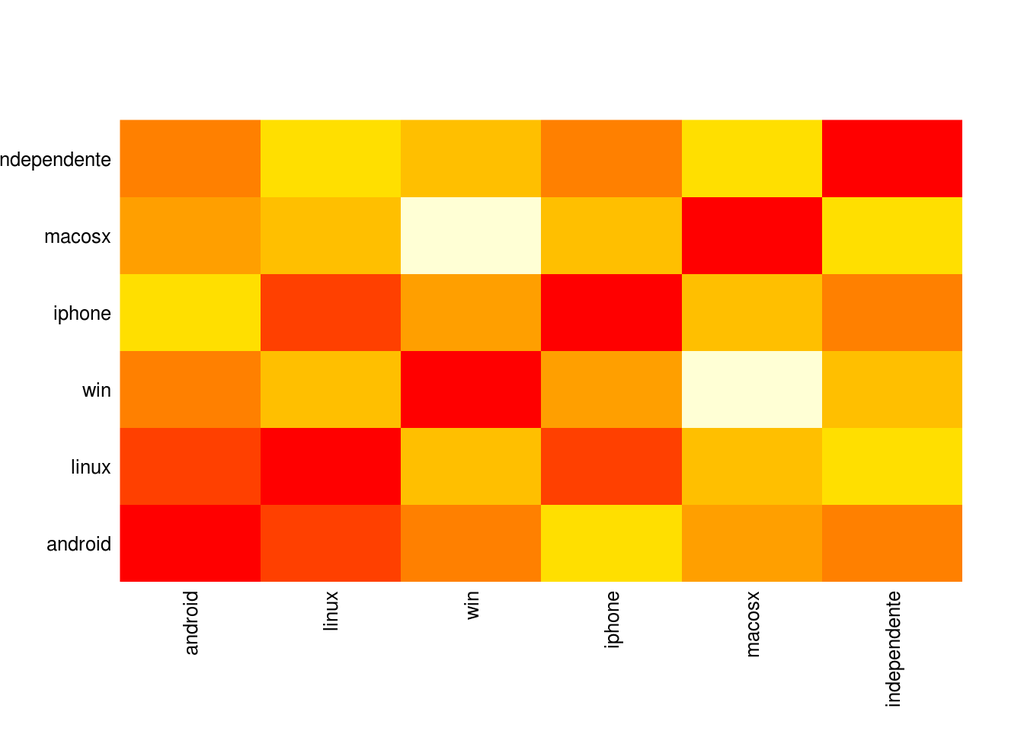

###### Crosstable entre as plataformas (count) (desenvolvedor)

|  | independente | linux | win | macosx | android | iphone |
| --- | --- | --- | --- | --- | --- | --- |
| independente | 45 | 19 | 13 | 14 | 9 | 8 |
| linux | 19 | 35 | 12 | 11 | 5 | 4 |
| win | 13 | 12 | 19 | 11 | 5 | 5 |
| macosx | 14 | 11 | 11 | 14 | 5 | 5 |
| android | 9 | 5 | 5 | 5 | 12 | 5 |
| iphone | 8 | 4 | 5 | 5 | 5 | 9 |

###### Crosstable entre as plataformas (support) (desenvolvedor)

|  | independente | linux | win | macosx | android | iphone |
| --- | --- | --- | --- | --- | --- | --- |
| independente | 0.6338028 | 0.2676056 | 0.1830986 | 0.1971831 | 0.1267606 | 0.1126761 |
| linux | 0.2676056 | 0.4929577 | 0.1690141 | 0.1549296 | 0.0704225 | 0.0563380 |
| win | 0.1830986 | 0.1690141 | 0.2676056 | 0.1549296 | 0.0704225 | 0.0704225 |
| macosx | 0.1971831 | 0.1549296 | 0.1549296 | 0.1971831 | 0.0704225 | 0.0704225 |
| android | 0.1267606 | 0.0704225 | 0.0704225 | 0.0704225 | 0.1690141 | 0.0704225 |
| iphone | 0.1126761 | 0.0563380 | 0.0704225 | 0.0704225 | 0.0704225 | 0.1267606 |

##### QP4.1 - Qual a quantidade de plataformas que os desenvolvedores dão suporte?

##### Consideramos as plataformas Windows, Linux, macOS, iPhone e Android nesta contagem.

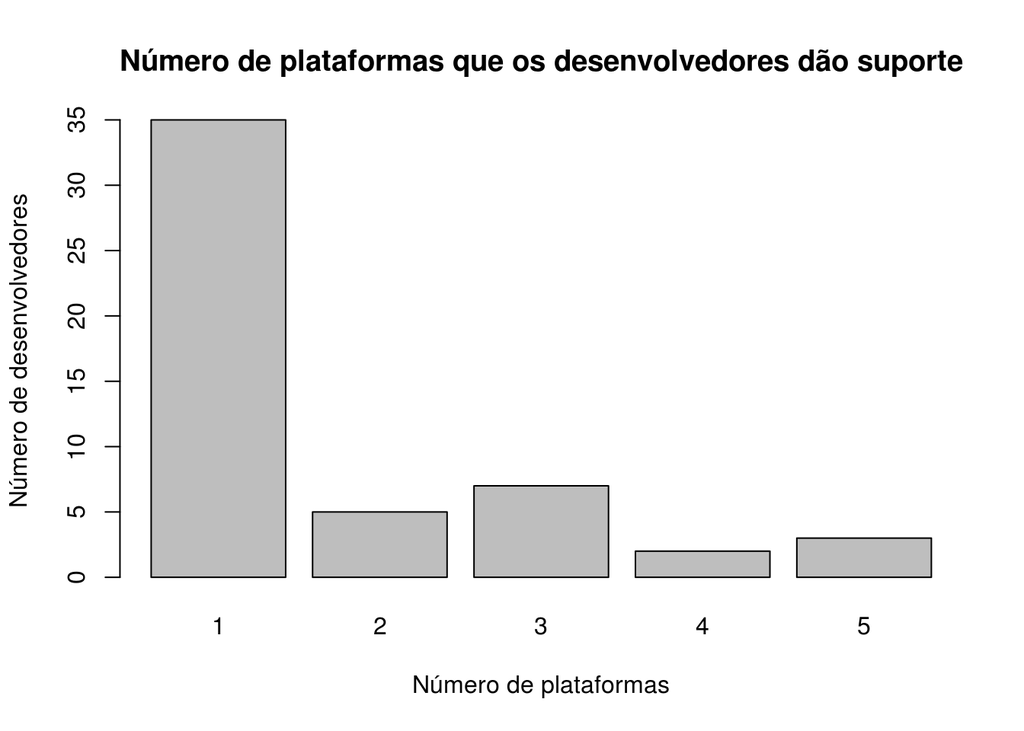

##### QP4.2 - Dos desenvolvedores que trabalham com uma plataforma, como é a distribuição das plataformas?

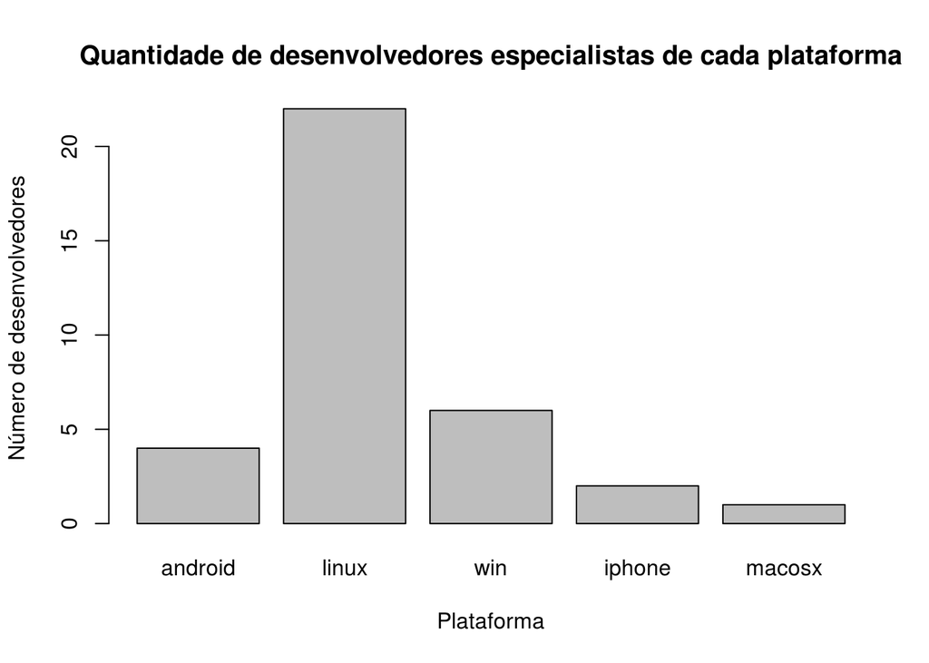

##### QP4.3 - Dos desenvolvedores generalistas, qual a quantidade de plataformas que eles dão suporte?

| n_platform | n_dev_gen | porc_gen |
| --- | --- | --- |
| 2 | 5 | 29.4 |
| 3 | 7 | 41.2 |
| 4 | 2 | 11.8 |
| 5 | 3 | 17.6 |

#### QP5 - Existem relações entre os conjuntos de plataformas modificadas em um commit?

###### Consideramos nesta analise as plataformas suportadas pela biblioteca e o código independente é interpretado como uma plataforma.

|  | lhs |  | rhs | support | confidence | lift | count |
| --- | --- | --- | --- | --- | --- | --- | --- |
| [1] | {Linux,Windows} | => | {Independente} | 0.0170081 | 0.9166667 | 1.846898 | 44 |
| 2 | {Windows,macOS} | => | {Independente} | 0.0081175 | 0.8400000 | 1.692430 | 21 |
| 3 | {Linux,macOS} | => | {Independente} | 0.0077310 | 0.9090909 | 1.831634 | 20 |
| 4 | {Android,Windows} | => | {Independente} | 0.0061848 | 0.9411765 | 1.896280 | 16 |
| 5 | {Linux,Windows,macOS} | => | {Independente} | 0.0061848 | 0.9411765 | 1.896280 | 16 |
| [6] | {Linux,macOS,Independente} | => | {Windows} | 0.0061848 | 0.8000000 | 3.409555 | 16 |
| [7] | {Android,Linux} | => | {Independente} | 0.0054117 | 0.8750000 | 1.762948 | 14 |
| [8] | {Android,iPhone} | => | {Independente} | 0.0050251 | 0.8125000 | 1.637023 | 13 |
| [9] | {Android,Linux} | => | {Windows} | 0.0050251 | 0.8125000 | 3.462829 | 13 |
| [10] | {Linux,iPhone} | => | {Windows} | 0.0046386 | 0.8571429 | 3.653095 | 12 |

###### Afinidade (commit)

|  | Android | Linux | Windows | iPhone | macOS | Independente |
| --- | --- | --- | --- | --- | --- | --- |
| Android | 0.0000000 | 0.0256410 | 0.0225764 | 0.0477612 | 0.0265957 | 0.0226148 |
| Linux | 0.0256410 | 0.0000000 | 0.0463320 | 0.0215054 | 0.0324484 | 0.0589296 |
| Windows | 0.0225764 | 0.0463320 | 0.0000000 | 0.0179257 | 0.0310559 | 0.0671558 |
| iPhone | 0.0477612 | 0.0215054 | 0.0179257 | 0.0000000 | 0.0352645 | 0.0236439 |
| macOS | 0.0265957 | 0.0324484 | 0.0310559 | 0.0352645 | 0.0000000 | 0.0371645 |
| Independente | 0.0226148 | 0.0589296 | 0.0671558 | 0.0236439 | 0.0371645 | 0.0000000 |

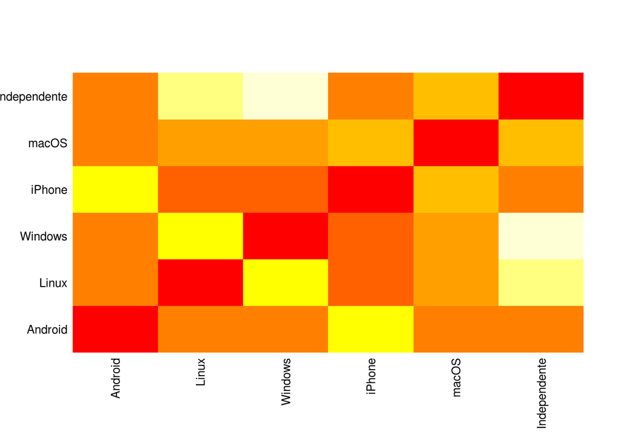

###### Crosstable entre as plataformas (count) (commit)

|  | Independente | Windows | Linux | macOS | iPhone | Android |
| --- | --- | --- | --- | --- | --- | --- |
| Independente | 1284 | 119 | 98 | 54 | 34 | 32 |
| Windows | 119 | 607 | 48 | 25 | 14 | 17 |
| Linux | 98 | 48 | 477 | 22 | 14 | 16 |
| macOS | 54 | 25 | 22 | 223 | 14 | 10 |
| iPhone | 34 | 14 | 14 | 14 | 188 | 16 |
| Android | 32 | 17 | 16 | 10 | 16 | 163 |

###### Crosstable entre as plataformas (support) (commit)

|  | Independente | Windows | Linux | macOS | iPhone | Android |
| --- | --- | --- | --- | --- | --- | --- |
| Independente | 0.4963278 | 0.0459992 | 0.0378817 | 0.0208736 | 0.0131426 | 0.0123695 |
| Windows | 0.0459992 | 0.2346347 | 0.0185543 | 0.0096637 | 0.0054117 | 0.0065713 |
| Linux | 0.0378817 | 0.0185543 | 0.1843835 | 0.0085041 | 0.0054117 | 0.0061848 |
| macOS | 0.0208736 | 0.0096637 | 0.0085041 | 0.0862002 | 0.0054117 | 0.0038655 |
| iPhone | 0.0131426 | 0.0054117 | 0.0054117 | 0.0054117 | 0.0726710 | 0.0061848 |
| Android | 0.0123695 | 0.0065713 | 0.0061848 | 0.0038655 | 0.0061848 | 0.0630073 |

#### QP5.1 - Quantas plataformas são modificadas em conjunto em uma tarefa de manutenção?

| Platform | Commit | % |
| --- | --- | --- |
| 0 | 1052 | 40.7 |
| 1 | 1457 | 56.3 |
| 2 | 53 | 2.0 |
| 3 | 13 | 0.5 |
| 4 | 4 | 0.2 |
| 5 | 8 | 0.3 |

##### QP5.2 - Dos commits que modificaram uma plataforma, como é a distribuição de plataformas?

##### Distribuição de plataformas dos commits que modificaram apenas o código especifico de uma plataforma

| Platform | Mod. Total | Mod. uma | % moduma_modtotal | modtotal_summodtotal |
| --- | --- | --- | --- | --- |
| Android | 163 | 127 | 77.91411 | 9.831122 |
| iPhone | 188 | 147 | 78.19149 | 11.338963 |
| Linux | 477 | 373 | 78.19706 | 28.769602 |
| macOS | 223 | 162 | 72.64574 | 13.449940 |
| Windows | 607 | 480 | 79.07743 | 36.610374 |

##### QP5.3 - Qual a porcentagem de commits que modificaram o código independente junto com algum código específico de plataforma?

##### Neste calculo de porcentagem consideramos como denominador o número total de commits que modificaram o código específico de alguma

Total de commits: [1] 2587

Total de commits que modificaram o código específico de pelo menos uma plataforma (Denominador): [1] 1535

Porcentagem: [1] 15.11401

#### QP2.1 - A equipe de desenvolvimento de bibliotecas multiplataforma tende a tornar-se mais generalista ou especialista ao longo do tempo?

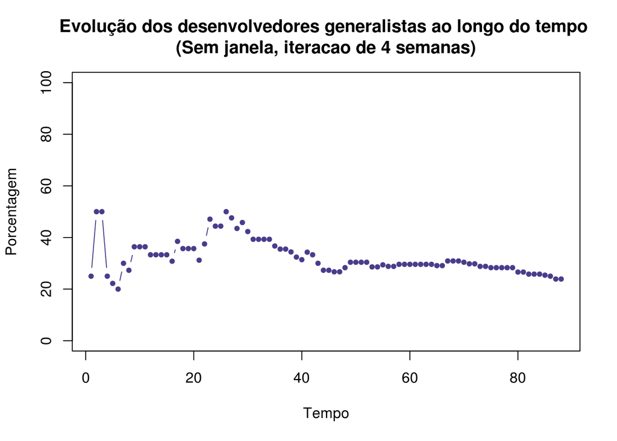

```
KPSS Test for Level Stationarity
```

data: dev_all_time2$porcentage KPSS Level = 1.2384, Truncation lag parameter = 2, p-value = 0.01

```
KPSS Test for Trend Stationarity
```

data: dev_all_time2$porcentage KPSS Trend = 0.20625, Truncation lag parameter = 2, p-value = 0.01366

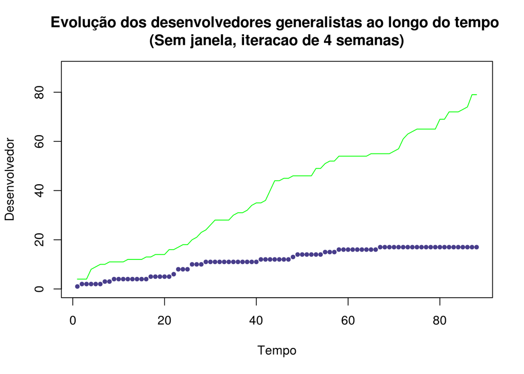

```
KPSS Test for Level Stationarity
```

data: dev_all_time2$n KPSS Level = 2.8697, Truncation lag parameter = 2, p-value = 0.01

```
KPSS Test for Trend Stationarity
```

data: dev_all_time2$n KPSS Trend = 0.57716, Truncation lag parameter = 2, p-value = 0.01

#### QP2.2 - Dos desenvolvedores generalistas, eles tendem a trabalhar com mais plataformas ao longo do tempo?

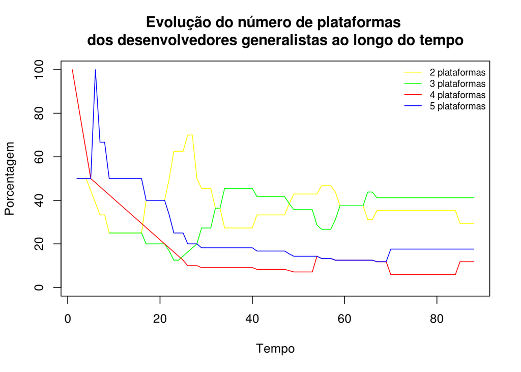

#### 2

```
KPSS Test for Level Stationarity
```

data: dev_gen_time2$porcentage KPSS Level = 0.19127, Truncation lag parameter = 2, p-value = 0.1

```
KPSS Test for Trend Stationarity
```

data: dev_gen_time2$porcentage KPSS Trend = 0.094429, Truncation lag parameter = 2, p-value = 0.1

#### 3

```
KPSS Test for Level Stationarity
```

data: dev_gen_time3$porcentage KPSS Level = 1.2217, Truncation lag parameter = 2, p-value = 0.01

```
KPSS Test for Trend Stationarity
```

data: dev_gen_time3$porcentage KPSS Trend = 0.21128, Truncation lag parameter = 2, p-value = 0.01177

#### 4

```
KPSS Test for Level Stationarity
```

data: dev_gen_time4$porcentage KPSS Level = 0.45178, Truncation lag parameter = 1, p-value = 0.05484

```
KPSS Test for Trend Stationarity
```

data: dev_gen_time4$porcentage KPSS Trend = 0.15202, Truncation lag parameter = 1, p-value = 0.04499

#### 5

```
KPSS Test for Level Stationarity
```

data: dev_gen_time5$porcentage KPSS Level = 1.8975, Truncation lag parameter = 2, p-value = 0.01

```
KPSS Test for Trend Stationarity
```

data: dev_gen_time5$porcentage KPSS Trend = 0.59203, Truncation lag parameter = 2, p-value = 0.01

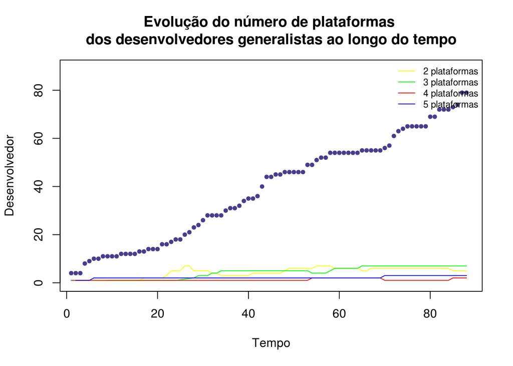

#### 2

```
KPSS Test for Level Stationarity
```

data: dev_gen_time2$n KPSS Level = 1.9432, Truncation lag parameter = 2, p-value = 0.01

```
KPSS Test for Trend Stationarity
```

data: dev_gen_time2$n KPSS Trend = 0.27511, Truncation lag parameter = 2, p-value = 0.01

#### 3

```
KPSS Test for Level Stationarity
```

data: dev_gen_time3$n KPSS Level = 2.2945, Truncation lag parameter = 2, p-value = 0.01

```
KPSS Test for Trend Stationarity
```

data: dev_gen_time3$n KPSS Trend = 0.28712, Truncation lag parameter = 2, p-value = 0.01

#### 4

```
KPSS Test for Level Stationarity
```

data: dev_gen_time4$n KPSS Level = 0.78599, Truncation lag parameter = 1, p-value = 0.01

```
KPSS Test for Trend Stationarity
```

data: dev_gen_time4$n KPSS Trend = 0.29177, Truncation lag parameter = 1, p-value = 0.01

#### 5

```
KPSS Test for Level Stationarity
```

data: dev_gen_time5$n KPSS Level = 1.8356, Truncation lag parameter = 2, p-value = 0.01

```
KPSS Test for Trend Stationarity
```

data: dev_gen_time5$n KPSS Trend = 0.34042, Truncation lag parameter = 2, p-value = 0.01

#### QP3.1 - Os desenvolvedores de bibliotecas multiplataforma tendem a especializar-se em dispositivos desktop ou mobile ao longo do tempo?

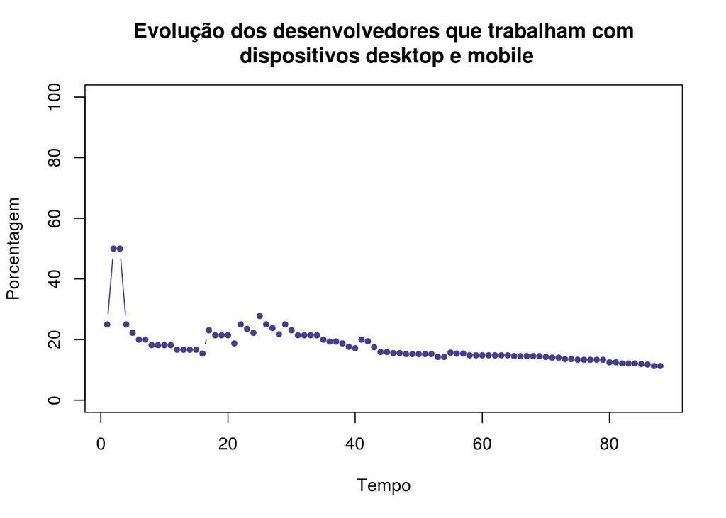

```
KPSS Test for Level Stationarity
```

data: devicetype_time2$porcentage KPSS Level = 1.7108, Truncation lag parameter = 2, p-value = 0.01

```
KPSS Test for Trend Stationarity
```

data: devicetype_time2$porcentage KPSS Trend = 0.072583, Truncation lag parameter = 2, p-value = 0.1

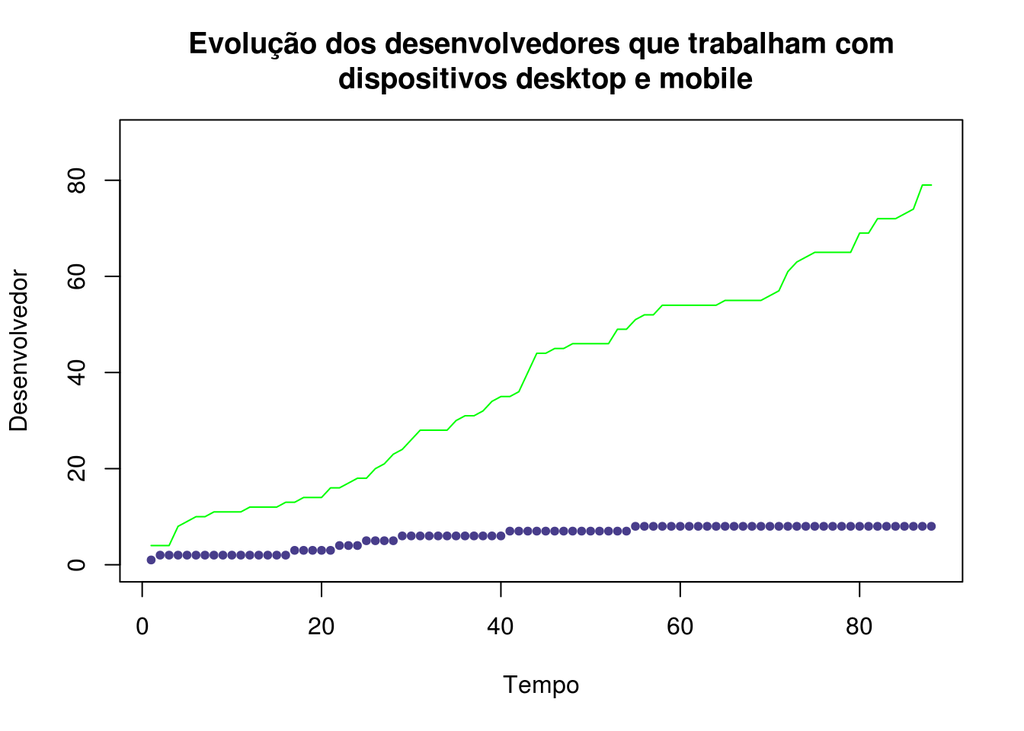

```
KPSS Test for Level Stationarity
```

data: devicetype_time2$developer KPSS Level = 2.7228, Truncation lag parameter = 2, p-value = 0.01

```
KPSS Test for Trend Stationarity
```

data: devicetype_time2$developer KPSS Trend = 0.65543, Truncation lag parameter = 2, p-value = 0.01